# Assignment_5

Cole Yagersz

## Introduction

The dataset Cereals.csv includes nutritional information, store display, and consumer ratings for 77 breakfast cereals.

Data Preprocessing. Remove all cereals with missing values.

● Apply hierarchical clustering to the data using Euclidean distance to the normalized measurements. Use Agnes to compare the clustering from single linkage, complete linkage, average linkage, and Ward. Choose the best method.

● How many clusters would you choose?

● Comment on the structure of the clusters and on their stability. Hint: To check stability, partition the data and see how well clusters formed based on one part apply to the other part. To do this:

● Cluster partition A

● Use the cluster centroids from A to assign each record in partition B (each record is assigned to the cluster with the closest centroid).

● Assess how consistent the cluster assignments are compared to the assignments based on all the data.

● The elementary public schools would like to choose a set of cereals to include in their daily cafeterias. Every day a different cereal is offered, but all cereals should support a healthy diet. For this goal, you are requested to find a cluster of “healthy cereals.” Should the data be normalized? If not, how should they be used in the cluster analysis? Load Libraries

```r
library(caret)
library(factoextra)
```

```r
library(ggplot2)
library(cluster)
```

Question 1:

Apply hierarchical clustering to the data using Euclidean distance to the normalized measurements. Use Agnes to compare the clustering from single linkage, complete linkage, average linkage, and Ward. Choose the best method

Read the data and cleaned Missing values.

```r
# Read the dataset
cereal <- read.csv("Cereals.csv")

# set row names to the utilities column
row.names(cereal) <- cereal[,1]

# remove the utility column
cereal <- cereal[,-1]


cereal_clean <- na.omit(cereal)

head(cereal_clean)
```

```
##                           mfr type calories protein fat sodium fiber carbo
## 100%_Bran                   N    C       70       4   1    130  10.0   5.0
## 100%_Natural_Bran           Q    C      120       3   5     15   2.0   8.0
## All-Bran                    K    C       70       4   1    260   9.0   7.0
## All-Bran_with_Extra_Fiber   K    C       50       4   0    140  14.0   8.0
## Apple_Cinnamon_Cheerios     G    C      110       2   2    180   1.5  10.5
## Apple_Jacks                 K    C      110       2   0    125   1.0  11.0
##                           sugars potass vitamins shelf weight cups   rating
## 100%_Bran                      6    280       25     3      1 0.33 68.40297
## 100%_Natural_Bran              8    135        0     3      1 1.00 33.98368
## All-Bran                       5    320       25     3      1 0.33 59.42551
## All-Bran_with_Extra_Fiber      0    330       25     3      1 0.50 93.70491
## Apple_Cinnamon_Cheerios       10     70       25     1      1 0.75 29.50954
## Apple_Jacks                   14     30       25     2      1 1.00 33.17409
```

Removed Categorical values so we can apply Euclidean Distance

```r
# Columns to drop
cols_to_remove <- c("mfr", "type", "shelf")

# Drop categorical variables
cereal_numeric <- cereal_clean[, !(names(cereal_clean) %in% cols_to_remove)]

summary(cereal_numeric)
```

```
##     calories      protein           fat        sodium          fiber
##  Min.   : 50   Min.   :1.000   Min.   :0   Min.   :  0.0   Min.   : 0.000
##  1st Qu.:100   1st Qu.:2.000   1st Qu.:0   1st Qu.:135.0   1st Qu.: 0.250
##  Median :110   Median :2.500   Median :1   Median :180.0   Median : 2.000
##  Mean   :107   Mean   :2.514   Mean   :1   Mean   :162.4   Mean   : 2.176
##  3rd Qu.:110   3rd Qu.:3.000   3rd Qu.:1   3rd Qu.:217.5   3rd Qu.: 3.000
##  Max.   :160   Max.   :6.000   Max.   :5   Max.   :320.0   Max.   :14.000
##      carbo           sugars           potass          vitamins
##  Min.   : 5.00   Min.   : 0.000   Min.   : 15.00   Min.   :  0.00
##  1st Qu.:12.00   1st Qu.: 3.000   1st Qu.: 41.25   1st Qu.: 25.00
##  Median :14.50   Median : 7.000   Median : 90.00   Median : 25.00
##  Mean   :14.73   Mean   : 7.108   Mean   : 98.51   Mean   : 29.05
##  3rd Qu.:17.00   3rd Qu.:11.000   3rd Qu.:120.00   3rd Qu.: 25.00
##  Max.   :23.00   Max.   :15.000   Max.   :330.00   Max.   :100.00
##      weight           cups            rating
##  Min.   :0.500   Min.   :0.2500   Min.   :18.04
##  1st Qu.:1.000   1st Qu.:0.6700   1st Qu.:32.45
##  Median :1.000   Median :0.7500   Median :40.25
##  Mean   :1.031   Mean   :0.8216   Mean   :42.37
##  3rd Qu.:1.000   3rd Qu.:1.0000   3rd Qu.:50.52
##  Max.   :1.500   Max.   :1.5000   Max.   :93.70
```

Normalized the data

```r
cereal_numeric_norm <- as.data.frame(scale(cereal_numeric))
row.names(cereal_numeric_norm) <- row.names(cereal_numeric)
head(cereal_numeric_norm)
```

```
##                             calories    protein        fat     sodium
## 100%_Bran                 -1.8659155  1.3817478  0.0000000 -0.3910227
## 100%_Natural_Bran          0.6537514  0.4522084  3.9728810 -1.7804186
## All-Bran                  -1.8659155  1.3817478  0.0000000  1.1795987
## All-Bran_with_Extra_Fiber -2.8737823  1.3817478 -0.9932203 -0.2702057
## Apple_Cinnamon_Cheerios    0.1498180 -0.4773310  0.9932203  0.2130625
## Apple_Jacks                0.1498180 -0.4773310 -0.9932203 -0.4514312
##                                 fiber      carbo     sugars     potass
## 100%_Bran                  3.22866747 -2.5001396 -0.2542051  2.5605229
## 100%_Natural_Bran         -0.07249167 -1.7292632  0.2046041  0.5147738
## All-Bran                   2.81602258 -1.9862220 -0.4836096  3.1248675
## All-Bran_with_Extra_Fiber  4.87924705 -1.7292632 -1.6306324  3.2659536
## Apple_Cinnamon_Cheerios   -0.27881412 -1.0868662  0.6634132 -0.4022862
## Apple_Jacks               -0.48513656 -0.9583868  1.5810314 -0.9666308
##                             vitamins     weight       cups     rating
## 100%_Bran                 -0.1818422 -0.2008324 -2.0856582  1.8549038
## 100%_Natural_Bran         -1.3032024 -0.2008324  0.7567534 -0.5977113
## All-Bran                  -0.1818422 -0.2008324 -2.0856582  1.2151965
## All-Bran_with_Extra_Fiber -0.1818422 -0.2008324 -1.3644493  3.6578436
## Apple_Cinnamon_Cheerios   -0.1818422 -0.2008324 -0.3038480 -0.9165248
## Apple_Jacks               -0.1818422 -0.2008324  0.7567534 -0.6553998
```

Used Euclidean on the normalized data

```r
cereal_dist <- dist(cereal_numeric_norm,method = "euclidean")
summary(cereal_dist)
```

```
##    Min. 1st Qu.  Median    Mean 3rd Qu.    Max.
##  0.1432  3.5213  4.4942  4.5957  5.5076 10.9839
```

Used hclust to compute and show the the single, complete, average, and ward linkages.

[figure not shown]

```r
hc1 <- hclust(cereal_dist, method = "single")
plot(hc1, hang = -1, ann = FALSE)
```

[figure not shown]

```r
hc2 <- hclust(cereal_dist, method = "complete")
plot(hc2, hang = -1, ann = FALSE)
```

[figure not shown]

```r
hc3 <- hclust(cereal_dist, method = "average")
plot(hc3, hang = -1, ann = FALSE)
```

[figure not shown]

```r
hc4 <- hclust(cereal_dist, method = "ward.D")
plot(hc4, hang = -1, ann = FALSE)
```

Used Agnes and found the best method to be ward based on the Agglomerative coefficient

```r
agnes_single <- agnes(cereal_numeric_norm, method = "single")
print(agnes_single$ac)
```

```
## [1] 0.6072384
```

```r
agnes_complete <- agnes(cereal_numeric_norm, method = "complete")
print(agnes_complete$ac)
```

```
## [1] 0.8469328
```

```r
agnes_average <- agnes(cereal_numeric_norm, method = "average")
print(agnes_average$ac)
```

```
## [1] 0.7881955
```

```r
agnes_ward <- agnes(cereal_numeric_norm, method = "ward")
print(agnes_ward$ac)
```

```
## [1] 0.9087265
```

Based on the results we got from comparing the different methods I found that the Ward method gives the best Agglomerative coefficient which is .9087.

Question 2:

How many clusters would you choose?

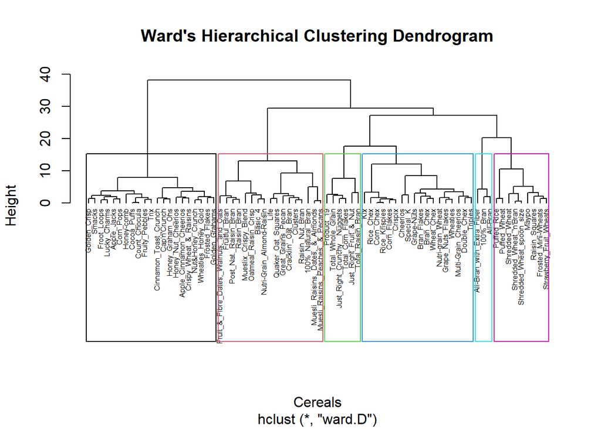

```r
plot(hc4,
     hang = -1,
     main = "Ward's Hierarchical Clustering Dendrogram",
     xlab = "Cereals",
     ylab = "Height",
     cex = 0.5)
rect.hclust(hc4,k=6,border=1:6)
```

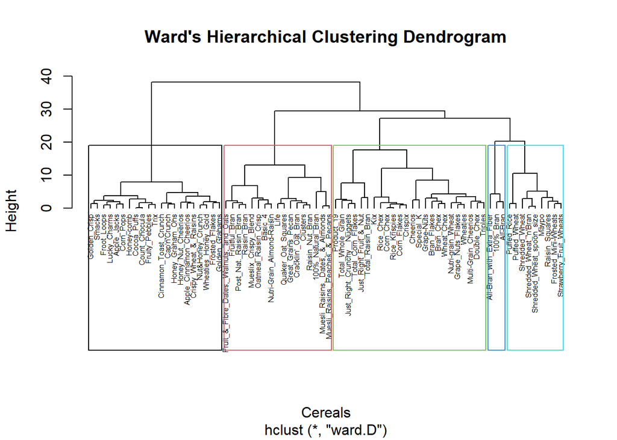

```r
plot(hc4,
     hang = -1,
     main = "Ward's Hierarchical Clustering Dendrogram",
     xlab = "Cereals",
     ylab = "Height",
     cex = 0.5)
rect.hclust(hc4,k=5,border=1:5)
```

I selected 6 clusters because the Ward dendrogram shows a jump in height when going from 6 to 5 clusters, showing that 6 clusters keeps the structure of the data.

```r
# Cut into k clusters
clusters <- cutree(hc4, k = 6)
table(clusters)
```

```
## clusters
##  1  2  3  4  5  6
##  3 17 21 18  9  6
```

Added the cluster number to the data frame.

```r
cereal_clusters <- data.frame(cereal_numeric_norm, Cluster = clusters)
head(cereal_clusters)
```

```
##                             calories    protein        fat     sodium
## 100%_Bran                 -1.8659155  1.3817478  0.0000000 -0.3910227
## 100%_Natural_Bran          0.6537514  0.4522084  3.9728810 -1.7804186
## All-Bran                  -1.8659155  1.3817478  0.0000000  1.1795987
## All-Bran_with_Extra_Fiber -2.8737823  1.3817478 -0.9932203 -0.2702057
## Apple_Cinnamon_Cheerios    0.1498180 -0.4773310  0.9932203  0.2130625
## Apple_Jacks                0.1498180 -0.4773310 -0.9932203 -0.4514312
##                                 fiber      carbo     sugars     potass
## 100%_Bran                  3.22866747 -2.5001396 -0.2542051  2.5605229
## 100%_Natural_Bran         -0.07249167 -1.7292632  0.2046041  0.5147738
## All-Bran                   2.81602258 -1.9862220 -0.4836096  3.1248675
## All-Bran_with_Extra_Fiber  4.87924705 -1.7292632 -1.6306324  3.2659536
## Apple_Cinnamon_Cheerios   -0.27881412 -1.0868662  0.6634132 -0.4022862
## Apple_Jacks               -0.48513656 -0.9583868  1.5810314 -0.9666308
##                             vitamins     weight       cups     rating Cluster
## 100%_Bran                 -0.1818422 -0.2008324 -2.0856582  1.8549038       1
## 100%_Natural_Bran         -1.3032024 -0.2008324  0.7567534 -0.5977113       2
## All-Bran                  -0.1818422 -0.2008324 -2.0856582  1.2151965       1
## All-Bran_with_Extra_Fiber -0.1818422 -0.2008324 -1.3644493  3.6578436       1
## Apple_Cinnamon_Cheerios   -0.1818422 -0.2008324 -0.3038480 -0.9165248       3
## Apple_Jacks               -0.1818422 -0.2008324  0.7567534 -0.6553998       3
```

Question 3:

Comment on the structure of the clusters and on their stability. Hint: To check stability, partition the data and see how well clusters formed based on one part apply to the other part. To do this:

● Cluster partition A

● Use the cluster centroids from A to assign each record in partition B (each record is assigned to the cluster with the closest centroid).

● Assess how consistent the cluster assignments are compared to the assignments based on all the data.

Partition the data

```r
set.seed(123)
train_index <- createDataPartition(y=cereal_clusters[,1],p=.5)[[1]]
partition_A <- cereal_numeric_norm[train_index, ]
partition_B <- cereal_numeric_norm[-train_index, ]
```

```r
# Cluster Partition A
hcA <- hclust(dist(partition_A), method = "ward.D2")
clusters_A <- cutree(hcA, k = 6)

centroids_A <- aggregate(partition_A, by = list(cluster = clusters_A),FUN = mean)


centroids_A <- centroids_A[, -1]


assign_to_nearest <- function(x, centers) {
  x <- as.numeric(x)
  centers <- as.matrix(centers)

  dists <- apply(centers, 1, function(row_center) sum((x - row_center)^2))
  which.min(dists)
}

assigned_B <- apply(partition_B, 1, assign_to_nearest, centers = centroids_A)

assigned_B
```

```
##                   100%_Bran           100%_Natural_Bran
##                           1                           2
##                    All-Bran     Apple_Cinnamon_Cheerios
##                           1                           3
##                 Apple_Jacks                     Basic_4
##                           3                           2
##                   Bran_Chex                Cap'n'Crunch
##                           2                           3
##                    Cheerios       Cinnamon_Toast_Crunch
##                           4                           3
##                 Cocoa_Puffs                   Corn_Chex
##                           3                           4
##                 Corn_Flakes      Crispy_Wheat_&_Raisins
##                           4                           3
##                 Double_Chex               Fruitful_Bran
##                           4                           2
##              Fruity_Pebbles            Honey_Graham_Ohs
##                           3                           3
##          Honey_Nut_Cheerios Just_Right_Crunchy__Nuggets
##                           3                           6
##                        Life                Lucky_Charms
##                           2                           3
##        Mueslix_Crispy_Blend   Nutri-Grain_Almond-Raisin
##                           2                           2
##        Oatmeal_Raisin_Crisp                  Product_19
##                           2                           6
##                 Puffed_Rice              Raisin_Squares
##                           5                           5
##                   Rice_Chex               Rice_Krispies
##                           4                           4
##      Shredded_Wheat_'n'Bran   Shredded_Wheat_spoon_size
##                           5                           5
##                      Smacks                   Special_K
##                           3                           4
##                  Wheat_Chex                    Wheaties
##                           4                           4
##         Wheaties_Honey_Gold
##                           3
```

```r
# Cluster full data
hc_full <- hclust(dist(cereal_numeric_norm), method = "ward.D2")
clusters_full <- cutree(hc_full, k = 6)

# Compare stability
table(assigned_B, clusters_full[-train_index])
```

```
##
## assigned_B  1  2  3  4  5  6
##          1  2  0  0  0  0  0
##          2  0  2  0  5  1  0
##          3  0  0 12  0  0  0
##          4  0  0  0  0  9  0
##          5  0  0  0  0  0  4
##          6  0  0  0  0  2  0
```

The stability table shows that most clusters remain consistent when assigning Partition B cereals based on Partition A centroids. Some cereals in cluster 2 shift between clusters, but overall, the clustering structure has medium to high stability.

Question 4:

The elementary public schools would like to choose a set of cereals to include in their daily cafeterias. Every day a different cereal is offered, but all cereals should support a healthy diet. For this goal, you are requested to find a cluster of “healthy cereals.” Should the data be normalized? If not, how should they be used in the cluster analysis?

```r
# Cluster summaries for the numeric variables
cluster_summary <- aggregate(cereal_numeric, by = list(Cluster = cereal_clusters$Cluster), FUN = mean)
cluster_summary
```

```
##   Cluster  calories  protein       fat     sodium      fiber     carbo
## 1       1  63.33333 4.000000 0.6666667 176.666667 11.0000000  6.666667
## 2       2 123.52941 3.235294 2.1176471 152.941176  3.1764706 13.705882
## 3       3 110.95238 1.523810 1.0000000 168.571429  0.5714286 12.428571
## 4       4 103.33333 2.722222 0.5000000 226.666667  1.7777778 18.277778
## 5       5  82.22222 2.444444 0.1111111   1.666667  2.1111111 15.333333
## 6       6 116.66667 2.666667 0.8333333 208.333333  1.8333333 18.166667
##      sugars    potass  vitamins   weight      cups   rating
## 1  3.666667 310.00000  25.00000 1.000000 0.3866667 73.84446
## 2  9.058824 152.05882  23.52941 1.155882 0.6676471 39.05834
## 3 11.476190  47.38095  25.00000 1.000000 0.8752381 28.66112
## 4  3.388889  77.22222  25.00000 1.000000 0.9177778 47.35266
## 5  2.333333  90.55556  11.11111 0.870000 0.8488889 63.01840
## 6  6.333333  95.83333 100.00000 1.133333 0.9583333 38.09835
```